# Homework Assignment 1

Adam Kass & Jacob Shelton & Syed Ahmad

Assigned: Sep 18, 2018, Due Sep 25, 2018 11:59PM

##### This homework is due by **11:59PM on Tue Sep 25**. To complete this assignment, follow these steps:

1. Download the `HW1.Rmd` file from Canvas
2. Open `HW1.Rmd` in RStudio.
3. Replace the “Your Name Here” text in the `author:` field with names of the students in HW team.
4. Supply your solutions to the homework by editing `HW1.Rmd`.
5. When you have completed the homework and have **checked** that your code both runs in the Console and knits correctly when you click `Knit HTML`, rename the R Markdown file to `HW1_YourNamesHere.Rmd`, and submit on Canvas. (YourNameHere should be changed to your own names.) You should submit both the RMD file and its html output.
6. Run your code in the Console and Knit HTML frequently to check for errors.
7. You may find it easier to solve a problem by interacting only with the Console at first.
8. Note - you can insert an R block for writing your R code by either clicking the **insert** button or pressing Control-Alt-I.

### Problem 1: Vectors

Let’s first start working with vectors. I am providing you with the following vector:

```r
somedata <- c(10.4, 9.8, 5.6, 4,9, 2,4, 3.1, 7.2, 6.4, 8.8, 12.5, 21.7)
```

I am asking you to do the tasks below. For each of these, you should insert a new R code block and type your code there.

What is the 5th value in vector `somedata`

```r
somedata[5]
```

```
## [1] 9
```

Show all values except the 5th value in vector `somedata`

```r
somedata[-5]
```

```
##  [1] 10.4  9.8  5.6  4.0  2.0  4.0  3.1  7.2  6.4  8.8 12.5 21.7
```

Calculate how many values there are in the vector `somedata`

```r
length(somedata)
```

```
## [1] 13
```

Calculate the difference between the maximum value and the minimum value in the vector `somedata`

```r
max(somedata)-min(somedata)
```

```
## [1] 19.7
```

Show all values in `somedata` more than 10

```r
greaterthanten <- somedata > 10
somedata[greaterthanten]
```

```
## [1] 10.4 12.5 21.7
```

Check whether the value 7.2 exists in the vector `somedata` or not. Code should output `TRUE` or `FALSE` depending upon whether the value exists or not in the vector.

```r
any(somedata==7.2)
```

```
## [1] TRUE
```

### Problem 2: Factors

Assume that we have collected address data from several students. We are storing the state of residence information in a vector named `student.state`. I have created the vector for you below.

```r
student.state <- c("MI", "IL", "NY", "MI", "NY", "HI", "IL", "MI", "MI", "NY")
```

I am asking you to do the tasks below. Again do them in separate R code blocks.

Convert the contents of student.state into factors (look up command `as.factor`)

```r
student.state.factor <- as.factor(student.state)
```

Count the number of levels in the factor created above (Useful command: `levels`)

```r
nlevels(student.state.factor)
```

```
## [1] 4
```

Figure out which state(s) appears in the list only once (this is a hard one!)

```r
str(student.state.factor)
```

```
##  Factor w/ 4 levels "HI","IL","MI",..: 3 2 4 3 4 1 2 3 3 4
```

```r
once <- summary(student.state.factor)

names(once[once == 1])
```

```
## [1] "HI"
```

```r
# HI
```

### Problem 3: Data frame basics

We will continue working with the nycflights13 dataset we looked at last class. Please be sure to keep the data file in the same directory as the RMD file.

First - read the data into an object named `nyc`.

```r
# Write code below to import nycflightsjan13 dataset into an object named nyc
nyc <- read.csv("nycflightsjan13.csv")
print("Str")
```

```
## [1] "Str"
```

```r
str(nyc)
```

```
## 'data.frame':    27004 obs. of  17 variables:
##  $ X        : int  1 2 3 4 5 6 7 8 9 10 ...
##  $ year     : int  2013 2013 2013 2013 2013 2013 2013 2013 2013 2013 ...
##  $ month    : int  1 1 1 1 1 1 1 1 1 1 ...
##  $ day      : int  1 1 1 1 1 1 1 1 1 1 ...
##  $ dep_time : int  517 533 542 544 554 554 555 557 557 558 ...
##  $ dep_delay: int  2 4 2 -1 -6 -4 -5 -3 -3 -2 ...
##  $ arr_time : int  830 850 923 1004 812 740 913 709 838 753 ...
##  $ arr_delay: int  11 20 33 -18 -25 12 19 -14 -8 8 ...
##  $ carrier  : Factor w/ 16 levels "9E","AA","AS",..: 12 12 2 4 5 12 4 6 4 2 ...
##  $ tailnum  : Factor w/ 3149 levels "","N0EGMQ","N10156",..: 170 448 1968 2544 2147 933 1524 2605 1816 960 ...
##  $ flight   : int  1545 1714 1141 725 461 1696 507 5708 79 301 ...
##  $ origin   : Factor w/ 3 levels "EWR","JFK","LGA": 1 3 2 2 3 1 1 3 2 3 ...
##  $ dest     : Factor w/ 94 levels "ALB","ATL","AUS",..: 39 39 51 9 2 61 31 38 47 61 ...
##  $ air_time : int  227 227 160 183 116 150 158 53 140 138 ...
##  $ distance : int  1400 1416 1089 1576 762 719 1065 229 944 733 ...
##  $ hour     : int  5 5 5 5 5 5 5 5 5 5 ...
##  $ minute   : int  17 33 42 44 54 54 55 57 57 58 ...
```

```r
print("Summary")
```

```
## [1] "Summary"
```

```r
summary(nyc)
```

```
##        X              year          month        day           dep_time
##  Min.   :    1   Min.   :2013   Min.   :1   Min.   : 1.00   Min.   :   1
##  1st Qu.: 6752   1st Qu.:2013   1st Qu.:1   1st Qu.: 8.00   1st Qu.: 907
##  Median :13502   Median :2013   Median :1   Median :16.00   Median :1409
##  Mean   :13502   Mean   :2013   Mean   :1   Mean   :15.99   Mean   :1347
##  3rd Qu.:20253   3rd Qu.:2013   3rd Qu.:1   3rd Qu.:24.00   3rd Qu.:1738
##  Max.   :27004   Max.   :2013   Max.   :1   Max.   :31.00   Max.   :2359
##                                                             NA's   :521
##    dep_delay          arr_time      arr_delay          carrier
##  Min.   : -30.00   Min.   :   1   Min.   : -70.00   UA     :4637
##  1st Qu.:  -5.00   1st Qu.:1118   1st Qu.: -15.00   B6     :4427
##  Median :  -2.00   Median :1556   Median :  -3.00   EV     :4171
##  Mean   :  10.04   Mean   :1523   Mean   :   6.13   DL     :3690
##  3rd Qu.:   8.00   3rd Qu.:1946   3rd Qu.:  13.00   AA     :2794
##  Max.   :1301.00   Max.   :2400   Max.   :1272.00   MQ     :2271
##  NA's   :521       NA's   :536    NA's   :606       (Other):5014
##     tailnum          flight     origin          dest          air_time
##         :  155   Min.   :   1   EWR:9893   ATL    : 1396   Min.   : 20.0
##  N730MQ :   74   1st Qu.: 542   JFK:9161   ORD    : 1269   1st Qu.: 84.0
##  N739MQ :   73   Median :1459   LGA:7950   BOS    : 1245   Median :137.0
##  N713MQ :   70   Mean   :1959              MCO    : 1175   Mean   :154.2
##  N719MQ :   66   3rd Qu.:3750              FLL    : 1161   3rd Qu.:194.0
##  N734MQ :   66   Max.   :8500              LAX    : 1159   Max.   :667.0
##  (Other):26500                             (Other):19599   NA's   :606
##     distance         hour           minute
##  Min.   :  80   Min.   : 0.00   Min.   : 0.00
##  1st Qu.: 483   1st Qu.: 9.00   1st Qu.:16.00
##  Median : 872   Median :14.00   Median :31.00
##  Mean   :1007   Mean   :13.15   Mean   :31.72
##  3rd Qu.:1372   3rd Qu.:17.00   3rd Qu.:50.00
##  Max.   :4983   Max.   :23.00   Max.   :59.00
##                 NA's   :521     NA's   :521
```

I now would like you to answer the following - all in their own separate R code blocks.

1. Let’s first filter this data to small portions. For example: How many flights where there by United Airlines (code: UA) on Jan 12th 2013? Provide the answer as an **inline R code**.

```r
nrow(subset(nyc, nyc$carrier == "UA" & nyc$day == 12 ))
```

```
## [1] 112
```

2. Lets focus on Arrival Delay. First thing we want to figure is: a) What was the average arrival delay in Jan 2013? and b) Whats was the maximum arrival delay? c) What was the median arrival delay. Note: You will need to make sure that you take care of NA values using the na.rm = TRUE option as we did in class.

```r
#Average delay
avgdelay <- mean(nyc$arr_delay, na.rm = TRUE)
avgdelay
```

```
## [1] 6.129972
```

```r
#Maximum arrival delay
mad <- max(nyc$arr_delay, na.rm = TRUE)
mad
```

```
## [1] 1272
```

```r
#median
median <- median(nyc$arr_delay, na.rm = TRUE)
median
```

```
## [1] -3
```

3. Lets see if all airlines are equally terrible as far as flight arrival delays are concerned. For this question you will have to make sure that airline column is coded as a factor.

```r
airlinefactor <- as.factor(nyc$carrier)
```

1. Calculate average arrival delays by airline (Hint: look up the command `tapply`)

```r
delaybyairline <- tapply(nyc$arr_delay, nyc$carrier, mean, na.rm = TRUE)
delaybyairline
```

```
##          9E          AA          AS          B6          DL          EV
##  10.2074324   0.9823789   8.9677419   4.7171992  -4.4046512  25.1601917
##          F9          FL          HA          MQ          OO          UA
##  21.8305085   3.3179012  27.4838710   7.8837948 107.0000000   3.1755991
##          US          VX          WN          YV
##   1.4311454 -15.2802548   5.8862944  13.7692308
```

2. Draw a Bar Plot of Average Arrival Delays for all the Airlines (Hint: command for making a Bar Plot is simply `barplot`)

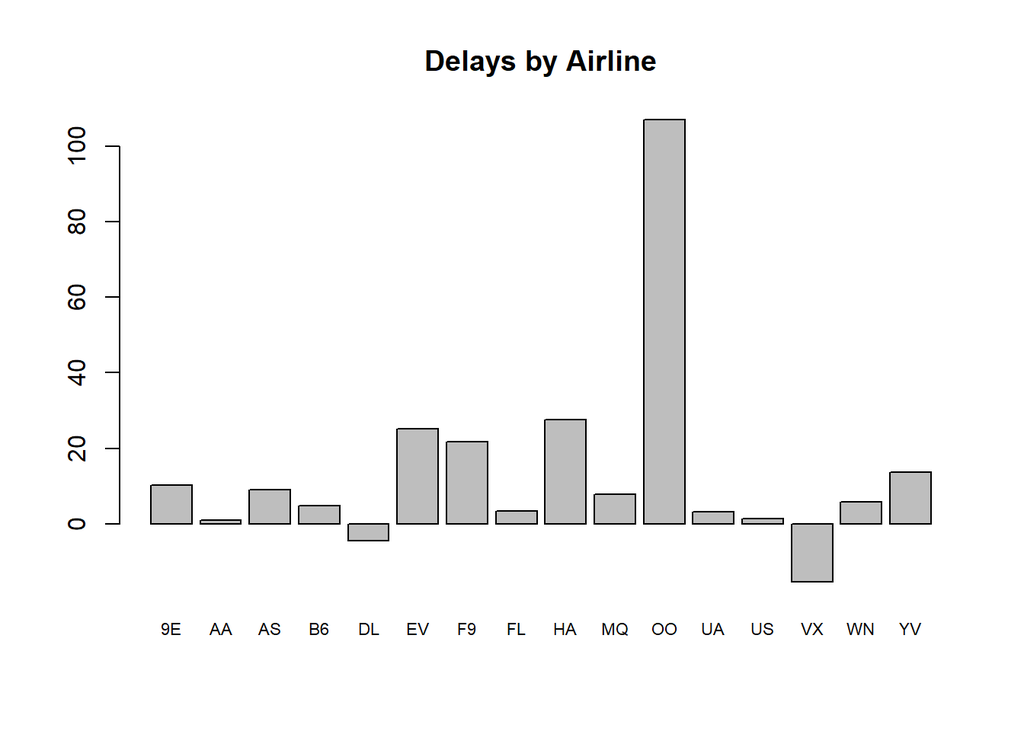

```r
barplot(delaybyairline, main = "Delays by Airline", cex.names = 0.7)
```

3. Which airline has the highest average delay? Which airline has the smallest average delay? Are there airlines that actually have negative average delay?

```r
#Highest Delay
names(delaybyairline[delaybyairline == max(delaybyairline)])
```

```
## [1] "OO"
```

```r
#lowestdelay
names(delaybyairline[delaybyairline == min(delaybyairline)])
```

```
## [1] "VX"
```

```r
#Negative?
any(delaybyairline < 0, TRUE)
```

```
## [1] TRUE
```

```r
#Yes, this is true!
```

That’s it. Once you are done, make sure everything works and knits well and then you can uplaod the RMD flile and the html output to Canvas.